# NBA 2024-2025 Salary Analysis

Author

Ian Cheung

# Introduction to NBA Salaries

The 2024-2025 NBA season shows a wide variety of salaries. Let’s look at the overall distribution of salaries across the league.

The histogram reveals a “long tail” distribution. While a small number of elite players earn upwards of $40 million, the vast majority of the league’s players falls into the lower salary brackets

Let’s look at the summary statistics for the entire league. The discrepancy between the mean and the median (the mean being significantly higher) confirms the influence of high-earning outliers on the league’s average.

# The Top 10

# Experience and Earning Power

Does staying in the league longer guarantee a higher salary? In this section, we explore the relationship between a player’s years of experience and their annual earnings.

The scatter plot indicates a general positive correlation between experience and salary. However, the high density of points at low experience and low salary represents the influx of rookie talent on fixed-scale contracts

# Team Payroll Rankings

Total payroll is a key indicator of a team’s championship aspirations. Here is how the 30 NBA teams rank in total player spending. This chart highlights the significant spending gaps between teams.

# Exploratory Analysis: Pay by Position

[figure not shown]

NBA Salary Summary Statistics ($)

[output not shown]

[figure not shown]

[figure not shown]

[figure not shown]

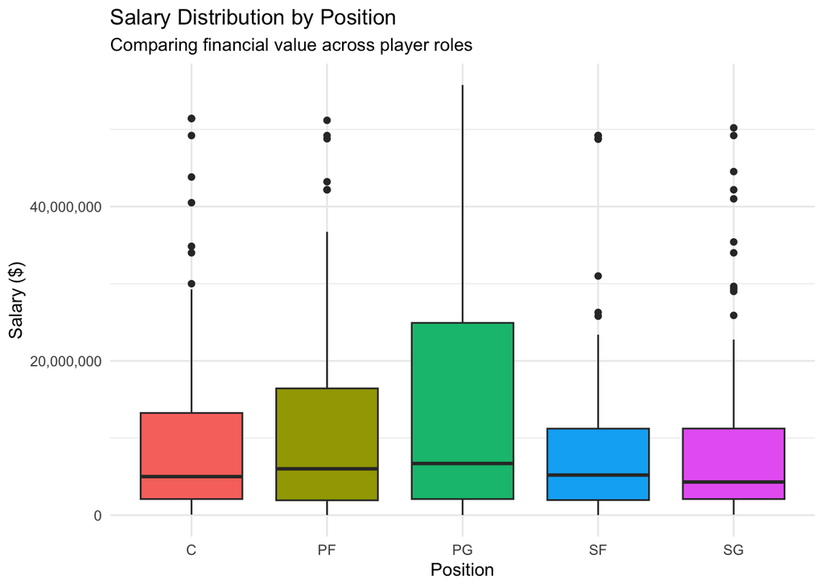